```python
import pandas as pd
import numpy as np
import random
import math as m
import matplotlib.pyplot as plt
import statistics as s
```

# Task 1

```python
rawdata = pd.read_csv('IE582_Fall21_HW2_q1_data.csv')
```

```python
lev = (rawdata['class'] == 'a')
```

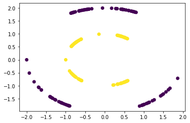

```python
plt.scatter(rawdata['X1'], rawdata['X2'], c= lev)
```

# A

```python
from sklearn.decomposition import PCA
```

```python
pca_part1 = PCA(n_components=1)
principalComponents = pca_part1.fit_transform(rawdata[['X1','X2']])
```

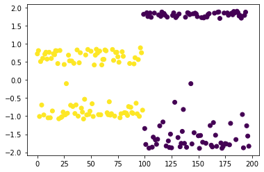

```python
plt.scatter(range(0,principalComponents.shape[0]),principalComponents, c= lev)
```

# B

```python
from sklearn.manifold import MDS
```

The Default dissimilarity calculation method in sklearn MDS is euclidean distance

```python
mds_part1 = MDS(n_components=1)
MultiDimensionalScaling = mds_part1.fit_transform(rawdata[['X1','X2']])
```

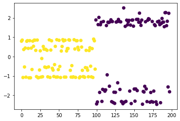

```python
plt.scatter(range(0,MultiDimensionalScaling.shape[0]),MultiDimensionalScaling, c= lev)
```

Lets try manhattan distance too (L1 Distance)

```python
from sklearn.metrics.pairwise import manhattan_distances
```

```python
dist_manhattan = manhattan_distances(rawdata[['X1','X2']])
```

```python
mds_part1_2 = MDS(n_components= 1,dissimilarity='precomputed', random_state=0)

MultiDimensionalScaling_L1 = mds_part1_2.fit_transform(dist_manhattan)
```

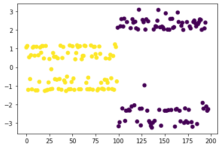

```python
plt.scatter(range(0,MultiDimensionalScaling_L1.shape[0]),MultiDimensionalScaling_L1, c= lev)
```

# C

1- PCA results in a fair discrimination in terms of classes of the data. However some of the points around 125-150 are coincide with the other class points in 1-D. Therefore, it seems mostly successfull despite those misclassified points. 2- MDS with L1 Norm seems even better than L2 Norm as there seems only 1 data point which is misclassified visually. 3- MDS with L2 Norm seems performing better than PCA as there is almost no points with wrong classification. As a result, MDS is more successfull than PCA in this particular problem.

# D

```python
rawdata['X1^2'] = rawdata['X1']**(2)
rawdata['X2^2'] = rawdata['X2']**(2)
rawdata['X1X2'] = rawdata['X1']*rawdata['X2']
```

```python
rawdata
```

|  | X1 | X2 | class | X1^2 | X2^2 | X1X2 |
| --- | --- | --- | --- | --- | --- | --- |
| 0 | 0.569483 | 0.822003 | a | 0.324311 | 0.675689 | 0.468117 |
| 1 | 0.411469 | 0.911424 | a | 0.169307 | 0.830693 | 0.375023 |
| 2 | 0.417385 | -0.908730 | a | 0.174210 | 0.825790 | -0.379290 |
| 3 | -0.791828 | 0.610745 | a | 0.626991 | 0.373009 | -0.483604 |
| 4 | -0.806777 | -0.590857 | a | 0.650889 | 0.349111 | 0.476689 |
| ... | ... | ... | ... | ... | ... | ... |
| 193 | -0.662932 | 1.886934 | b | 0.439479 | 3.560521 | -1.250910 |
| 194 | 0.316428 | 1.974810 | b | 0.100127 | 3.899873 | 0.624885 |
| 195 | -1.625464 | -1.165275 | b | 2.642134 | 1.357866 | 1.894113 |
| 196 | -1.378755 | -1.448804 | b | 1.900966 | 2.099034 | 1.997547 |
| 197 | -1.005258 | -1.729005 | b | 1.010543 | 2.989457 | 1.738095 |

198 rows × 6 columns

```python
pca = PCA(n_components=1)
principalComponents_ext = pca.fit_transform(rawdata[['X1','X2', 'X1^2','X2^2','X1X2']])
```

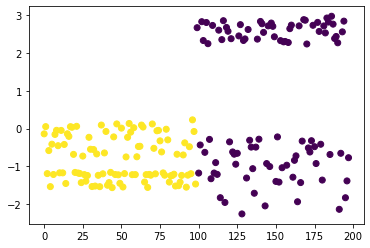

```python
plt.scatter(range(0,principalComponents_ext.shape[0]),principalComponents_ext, c= lev)
```

As seen, the interaction and nonlinear terms cause pca to get worse in terms of discrimination in one dimension.

```python
pca.components_
```

```
array([[ 0.07766657,  0.71257596, -0.19184503,  0.66582496, -0.07794878]])
```

The eigenvectors of the pca are those as we have 1-D representation as the resulting representation

```python
pca.explained_variance_
```

[output not shown]

```python
pca5 = PCA(n_components=5)
principalComponents_ext5 = pca5.fit_transform(rawdata[['X1','X2', 'X1^2','X2^2','X1X2']])
```

```python
pca5.components_
```

```
array([[ 0.07766657,  0.71257596, -0.19184503,  0.66582496, -0.07794878],
       [-0.42317217, -0.07426701,  0.15328013,  0.27219612,  0.84724507],
       [ 0.21930469, -0.6092683 ,  0.27145989,  0.67993125, -0.21142519],
       [-0.73210164,  0.13942364,  0.49110581,  0.0249689 , -0.45031087],
       [ 0.4804434 ,  0.30995661,  0.79045892, -0.14020145,  0.16917239]])
```

```python
pca5.explained_variance_
```

```
array([2.49086525, 1.44256642, 1.28808119, 0.54559809, 0.30619998])
```

We could see that by taking 5 as the number of principle components, we could calculate the weight of each component in the explanation of total variance of the sample. Here, as seen first component has:

```python
pca5.explained_variance_ratio_
```

```
array([0.410133  , 0.23752553, 0.21208879, 0.08983536, 0.05041731])
```

41% of the total variance. Resultingly, in 1-component case, we could retain 41% of the total variation in the data.

```python
pca_part12 = PCA(n_components=2)
principalComponents12 = pca_part12.fit_transform(rawdata[['X1','X2']])
```

```python
pca_part12.explained_variance_ratio_
```

```
array([0.71943753, 0.28056247])
```

While in the first part, we could explain 72% variation with one component, now, with the addition of nonlinear terms, it reduced to 41%. Therefore, we could claim that the addition of interaction or nonlinear terms would not be beneficial in PCA.

# Task 2

```python
distmat = pd.read_csv('distance_matrix.csv', sep = ';')
```

```python
random.seed(1891)
```

```python
del distmat['Unnamed: 0']
```

```python
distmat
```

|  | ADANA | ADIYAMAN | AFYONKARAHİSAR | AĞRI | AMASYA | ANKARA | ANTALYA | ARTVİN | AYDIN | BALIKESİR | ... | BATMAN | ŞIRNAK | BARTIN | ARDAHAN | IĞDIR | YALOVA | KARABÜK | KİLİS | OSMANİYE | DÜZCE |
| --- | --- | --- | --- | --- | --- | --- | --- | --- | --- | --- | --- | --- | --- | --- | --- | --- | --- | --- | --- | --- | --- |
| 0 | NaN | 335.0 | 575.0 | 966.0 | 603.0 | 567.0 | 535.0 | 1035.0 | 874.0 | 903.0 | ... | 621.0 | 709.0 | 782.0 | 1042.0 | 1066.0 | 899.0 | 714.0 | 246.0 | 87.0 | 735.0 |
| 1 | 335.0 | NaN | 910.0 | 648.0 | 632.0 | 814.0 | 870.0 | 751.0 | 1209.0 | 1238.0 | ... | 303.0 | 471.0 | 1023.0 | 758.0 | 748.0 | 1147.0 | 955.0 | 210.0 | 248.0 | 976.0 |
| 2 | 575.0 | 910.0 | NaN | 1318.0 | 597.0 | 300.0 | 290.0 | 1243.0 | 345.0 | 328.0 | ... | 1196.0 | 1284.0 | 515.0 | 1351.0 | 1461.0 | 338.0 | 447.0 | 821.0 | 662.0 | 375.0 |
| 3 | 966.0 | 648.0 | 1318.0 | NaN | 738.0 | 1141.0 | 1428.0 | 396.0 | 1640.0 | 1569.0 | ... | 369.0 | 430.0 | 1175.0 | 310.0 | 143.0 | 1363.0 | 1106.0 | 814.0 | 879.0 | 1192.0 |
| 4 | 603.0 | 632.0 | 597.0 | 736.0 | NaN | 413.0 | 825.0 | 695.0 | 938.0 | 831.0 | ... | 796.0 | 982.0 | 437.0 | 783.0 | 881.0 | 625.0 | 368.0 | 639.0 | 608.0 | 454.0 |
| ... | ... | ... | ... | ... | ... | ... | ... | ... | ... | ... | ... | ... | ... | ... | ... | ... | ... | ... | ... | ... | ... |
| 76 | 899.0 | 1152.0 | 338.0 | 1361.0 | 625.0 | 407.0 | 601.0 | 1254.0 | 510.0 | 216.0 | ... | 1411.0 | 1562.0 | 371.0 | 1362.0 | 1472.0 | NaN | 350.0 | 1120.0 | 987.0 | 171.0 |
| 77 | 714.0 | 960.0 | 447.0 | 1104.0 | 368.0 | 215.0 | 734.0 | 970.0 | 788.0 | 556.0 | ... | 1164.0 | 1350.0 | 89.0 | 1078.0 | 1215.0 | 350.0 | NaN | 928.0 | 801.0 | 179.0 |
| 78 | 246.0 | 210.0 | 821.0 | 814.0 | 644.0 | 715.0 | 781.0 | 917.0 | 1120.0 | 1149.0 | ... | 469.0 | 557.0 | 1001.0 | 924.0 | 917.0 | 1125.0 | 933.0 | NaN | 159.0 | 949.0 |
| 79 | 87.0 | 248.0 | 662.0 | 879.0 | 613.0 | 579.0 | 622.0 | 948.0 | 961.0 | 990.0 | ... | 534.0 | 622.0 | 869.0 | 955.0 | 982.0 | 986.0 | 801.0 | 159.0 | NaN | 822.0 |
| 80 | 735.0 | 981.0 | 375.0 | 1190.0 | 454.0 | 236.0 | 638.0 | 1083.0 | 671.0 | 377.0 | ... | 1240.0 | 1391.0 | 200.0 | 1191.0 | 1301.0 | 171.0 | 179.0 | 954.0 | 822.0 | NaN |

81 rows × 81 columns

Making the distance matrix symmetric by copying the upper triangle to the lower triangle

```python
b = distmat.columns
for i in range(0,81):
    a = 0
    for j in b:
        distmat.iloc[a][b[i]] = distmat.iloc[i][j]
        a = a+1
```

```python
distmat
```

|  | ADANA | ADIYAMAN | AFYONKARAHİSAR | AĞRI | AMASYA | ANKARA | ANTALYA | ARTVİN | AYDIN | BALIKESİR | ... | BATMAN | ŞIRNAK | BARTIN | ARDAHAN | IĞDIR | YALOVA | KARABÜK | KİLİS | OSMANİYE | DÜZCE |
| --- | --- | --- | --- | --- | --- | --- | --- | --- | --- | --- | --- | --- | --- | --- | --- | --- | --- | --- | --- | --- | --- |
| 0 | NaN | 335.0 | 575.0 | 966.0 | 603.0 | 567.0 | 535.0 | 1035.0 | 874.0 | 903.0 | ... | 621.0 | 709.0 | 782.0 | 1042.0 | 1066.0 | 899.0 | 714.0 | 246.0 | 87.0 | 735.0 |
| 1 | 335.0 | NaN | 910.0 | 648.0 | 632.0 | 814.0 | 870.0 | 751.0 | 1209.0 | 1238.0 | ... | 303.0 | 471.0 | 1023.0 | 758.0 | 748.0 | 1147.0 | 955.0 | 210.0 | 248.0 | 976.0 |
| 2 | 575.0 | 910.0 | NaN | 1318.0 | 597.0 | 300.0 | 290.0 | 1243.0 | 345.0 | 328.0 | ... | 1196.0 | 1284.0 | 515.0 | 1351.0 | 1461.0 | 338.0 | 447.0 | 821.0 | 662.0 | 375.0 |
| 3 | 966.0 | 648.0 | 1318.0 | NaN | 738.0 | 1141.0 | 1428.0 | 396.0 | 1640.0 | 1569.0 | ... | 369.0 | 430.0 | 1175.0 | 310.0 | 143.0 | 1363.0 | 1106.0 | 814.0 | 879.0 | 1192.0 |
| 4 | 603.0 | 632.0 | 597.0 | 738.0 | NaN | 413.0 | 825.0 | 695.0 | 938.0 | 831.0 | ... | 796.0 | 982.0 | 437.0 | 783.0 | 881.0 | 625.0 | 368.0 | 639.0 | 608.0 | 454.0 |
| ... | ... | ... | ... | ... | ... | ... | ... | ... | ... | ... | ... | ... | ... | ... | ... | ... | ... | ... | ... | ... | ... |
| 76 | 899.0 | 1147.0 | 338.0 | 1363.0 | 625.0 | 407.0 | 600.0 | 1254.0 | 510.0 | 216.0 | ... | 1411.0 | 1557.0 | 371.0 | 1362.0 | 1506.0 | NaN | 350.0 | 1120.0 | 987.0 | 171.0 |
| 77 | 714.0 | 955.0 | 447.0 | 1106.0 | 368.0 | 215.0 | 733.0 | 970.0 | 788.0 | 556.0 | ... | 1162.0 | 1348.0 | 89.0 | 1078.0 | 1249.0 | 350.0 | NaN | 928.0 | 801.0 | 179.0 |
| 78 | 246.0 | 210.0 | 821.0 | 814.0 | 639.0 | 710.0 | 781.0 | 917.0 | 1120.0 | 1149.0 | ... | 469.0 | 557.0 | 996.0 | 924.0 | 914.0 | 1120.0 | 928.0 | NaN | 159.0 | 949.0 |
| 79 | 87.0 | 248.0 | 662.0 | 879.0 | 608.0 | 579.0 | 622.0 | 948.0 | 961.0 | 990.0 | ... | 534.0 | 622.0 | 869.0 | 955.0 | 979.0 | 987.0 | 801.0 | 159.0 | NaN | 822.0 |
| 80 | 735.0 | 976.0 | 375.0 | 1192.0 | 454.0 | 236.0 | 637.0 | 1083.0 | 671.0 | 377.0 | ... | 1240.0 | 1386.0 | 200.0 | 1191.0 | 1335.0 | 171.0 | 179.0 | 949.0 | 822.0 | NaN |

81 rows × 81 columns

```python
distmat = distmat.fillna(0)
```

```python
mds_part2 = MDS(n_components=2, dissimilarity='precomputed')
MultiDimensionalScaling2 = mds_part2.fit_transform(distmat)
```

```python
dd = MultiDimensionalScaling2.T
```

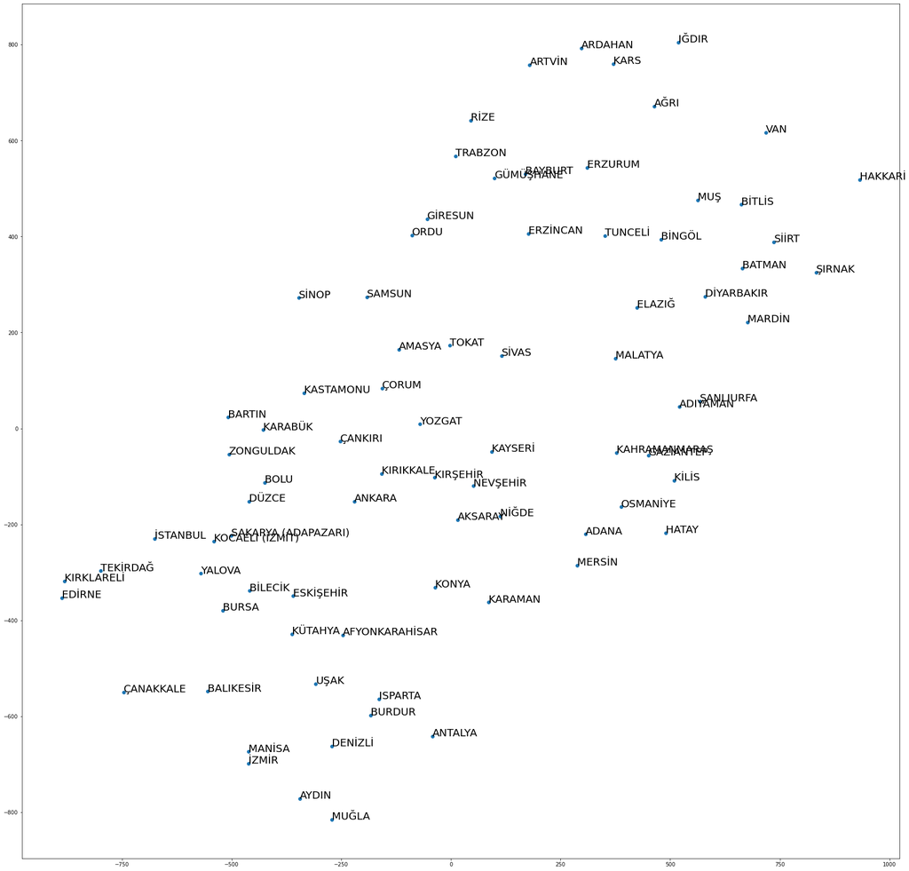

```python
fig, ax = plt.subplots()
fig.set_figwidth(30)
fig.set_figheight(30)
ax.scatter(dd[0], dd[1])

for i, city in enumerate(distmat.columns):
    ax.annotate(city, (dd[0][i], dd[1][i]), size  = 20)
```

As seen, it seems pretty close to the actual Turkey map. However, there seems to be some distance Samsun-Ordu, Tokat-Erzincan, Sivas-Elazığ, Kayseri-Malatya region. This may be an indicator of the mountainous terrain over that part of Turkey. Since MDS looks at the dissimilarity (road distance in our case), not the actual locations of the data points, it takes into account the geographical factors such as height and other physical existings on the roads (rivers, mountains, etc.). Therefore, it is expected that even if the distance between two cities by birds eye is small but the road is passing through mountainous terrain, then in this scatter plot the distance would seem longer.

# Task 3

```python
xtrain = pd.read_csv('uWaveGestureLibrary_X_TRAIN', sep = '\s+', header= None)
```

```python
ytrain = pd.read_csv('uWaveGestureLibrary_Y_TRAIN', sep = '\s+', header= None)
```

```python
ztrain = pd.read_csv('uWaveGestureLibrary_Z_TRAIN', sep = '\s+', header= None)
```

To get the velocity vectors:

```python
xtrain_v = xtrain.loc[:, xtrain.columns!=0].cumsum(axis = 1)
ytrain_v = ytrain.loc[:, ytrain.columns!=0].cumsum(axis = 1)
ztrain_v = ztrain.loc[:, ztrain.columns!=0].cumsum(axis = 1)
```

To get the position vectors:

```python
xtrain_p = xtrain_v.cumsum(axis = 1)
ytrain_p = ytrain_v.cumsum(axis = 1)
ztrain_p = ztrain_v.cumsum(axis = 1)
```

# A

```python
xtrain[[0]]
```

|  | 0 |
| --- | --- |
| 0 | 6.0 |
| 1 | 5.0 |
| 2 | 5.0 |
| 3 | 3.0 |
| 4 | 4.0 |
| ... | ... |
| 891 | 3.0 |
| 892 | 1.0 |
| 893 | 2.0 |
| 894 | 7.0 |
| 895 | 5.0 |

896 rows × 1 columns

Visualization of Gesture #1

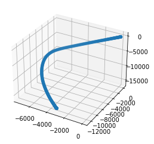

```python
fig = plt.figure()
ax = fig.add_subplot(projection='3d')
ax.scatter(xtrain_p.iloc[892] ,ytrain_p.iloc[892], ztrain_p.iloc[892])
plt.show()
```

Visualization of Gesture #2

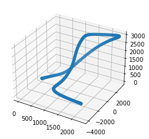

```python
fig = plt.figure()
ax = fig.add_subplot(projection='3d')
ax.scatter(xtrain_p.iloc[893] ,ytrain_p.iloc[893], ztrain_p.iloc[893])
plt.show()
```

Visualization of Gesture #3

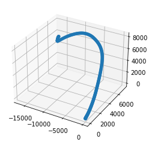

```python
fig = plt.figure()
ax = fig.add_subplot(projection='3d')
ax.scatter(xtrain_p.iloc[3] ,ytrain_p.iloc[3], ztrain_p.iloc[3])
plt.show()
```

Visualization of Gesture #4

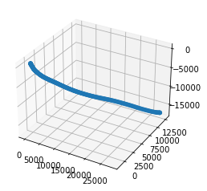

```python
fig = plt.figure()
ax = fig.add_subplot(projection='3d')
ax.scatter(xtrain_p.iloc[4] ,ytrain_p.iloc[4], ztrain_p.iloc[4])
plt.show()
```

Visualization of Gesture #5

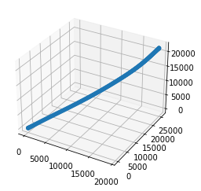

```python
fig = plt.figure()
ax = fig.add_subplot(projection='3d')
ax.scatter(xtrain_p.iloc[1] ,ytrain_p.iloc[1], ztrain_p.iloc[1])
plt.show()
```

Visualization of Gesture #6

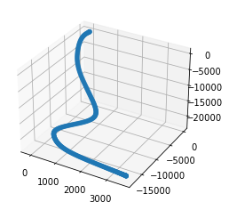

```python
fig = plt.figure()
ax = fig.add_subplot(projection='3d')
ax.scatter(xtrain_p.iloc[0] ,ytrain_p.iloc[0], ztrain_p.iloc[0])
plt.show()
```

Visualization of Gesture #7

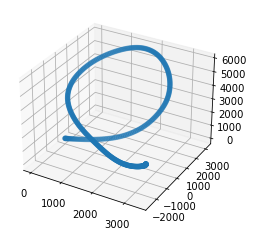

```python
fig = plt.figure()
ax = fig.add_subplot(projection='3d')
ax.scatter(xtrain_p.iloc[894] ,ytrain_p.iloc[894], ztrain_p.iloc[894])
plt.show()
```

Visualization of Gesture #8

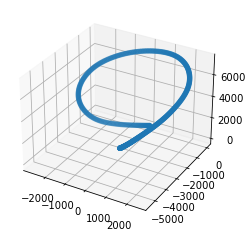

```python
fig = plt.figure()
ax = fig.add_subplot(projection='3d')
ax.scatter(xtrain_p.iloc[143] ,ytrain_p.iloc[143], ztrain_p.iloc[143])
plt.show()
```

# B

```python
conc_data = pd.concat([pd.concat([xtrain_p, ytrain_p], axis=1), ztrain_p], axis = 1)
```

```python
labels = xtrain[[0]]
```

```python
conc_data1 = pd.concat([labels,conc_data], axis = 1)[labels[0] == 1]
conc_data2 = pd.concat([labels,conc_data], axis = 1)[labels[0] == 2]
conc_data3 = pd.concat([labels,conc_data], axis = 1)[labels[0] == 3]
conc_data4 = pd.concat([labels,conc_data], axis = 1)[labels[0] == 4]
conc_data5 = pd.concat([labels,conc_data], axis = 1)[labels[0] == 5]
conc_data6 = pd.concat([labels,conc_data], axis = 1)[labels[0] == 6]
conc_data7 = pd.concat([labels,conc_data], axis = 1)[labels[0] == 7]
conc_data8 = pd.concat([labels,conc_data], axis = 1)[labels[0] == 8]
```

Let us see how the first two principle components are important in terms of variance explanation:

```python
pca_task31 = PCA(n_components=2)
principalComponents31 = pca_task31.fit_transform(conc_data1)

pca_task31.explained_variance_ratio_
```

```
array([0.48711174, 0.25629878])
```

```python
np.sum(pca_task31.explained_variance_ratio_)
```

```
0.7434105211268442
```

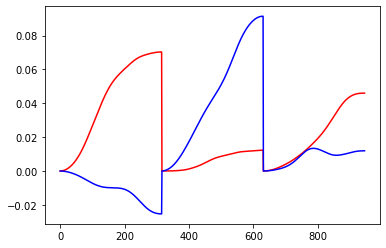

```python
plt.plot(range(0,pca_task31.components_.shape[1]),pca_task31.components_[0], color='red')
plt.plot(range(0,pca_task31.components_.shape[1]),pca_task31.components_[1], color='blue')
plt.show()
```

```python
pca_task32 = PCA(n_components=2)
principalComponents32 = pca_task32.fit_transform(conc_data2)

pca_task32.explained_variance_ratio_
```

```
array([0.54007801, 0.25439249])
```

```python
np.sum(pca_task32.explained_variance_ratio_)
```

```
0.794470508044071
```

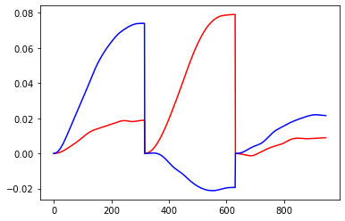

```python
plt.plot(range(0,pca_task32.components_.shape[1]),pca_task32.components_[0], color='red')
plt.plot(range(0,pca_task32.components_.shape[1]),pca_task32.components_[1], color='blue')
plt.show()
```

```python
pca_task33 = PCA(n_components=2)
principalComponents33 = pca_task33.fit_transform(conc_data3)

pca_task33.explained_variance_ratio_
```

```
array([0.4895243 , 0.39256085])
```

```python
np.sum(pca_task33.explained_variance_ratio_)
```

```
0.8820851423944582
```

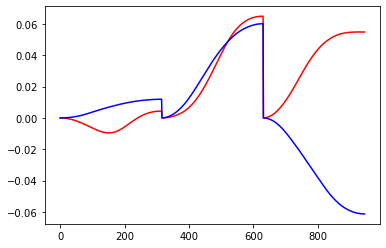

```python
plt.plot(range(0,pca_task33.components_.shape[1]),pca_task33.components_[0], color='red')
plt.plot(range(0,pca_task33.components_.shape[1]),pca_task33.components_[1], color='blue')
plt.show()
```

```python
pca_task34 = PCA(n_components=2)
principalComponents34 = pca_task34.fit_transform(conc_data4)

pca_task34.explained_variance_ratio_
```

```
array([0.55018154, 0.35496479])
```

```python
np.sum(pca_task34.explained_variance_ratio_)
```

```
0.905146329049118
```

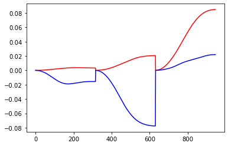

```python
plt.plot(range(0,pca_task34.components_.shape[1]),pca_task34.components_[0], color='red')
plt.plot(range(0,pca_task34.components_.shape[1]),pca_task34.components_[1], color='blue')
plt.show()
```

```python
pca_task35 = PCA(n_components=2)
principalComponents35 = pca_task35.fit_transform(conc_data5)

pca_task35.explained_variance_ratio_
```

```
array([0.76606369, 0.18070589])
```

```python
np.sum(pca_task35.explained_variance_ratio_)
```

```
0.9467695848917845
```

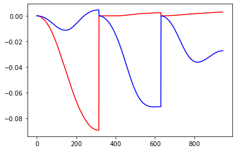

```python
plt.plot(range(0,pca_task35.components_.shape[1]),pca_task35.components_[0], color='red')
plt.plot(range(0,pca_task35.components_.shape[1]),pca_task35.components_[1], color='blue')
plt.show()
```

```python
pca_task36 = PCA(n_components=2)
principalComponents35 = pca_task36.fit_transform(conc_data6)

pca_task36.explained_variance_ratio_
```

```
array([0.56134712, 0.33499987])
```

```python
np.sum(pca_task36.explained_variance_ratio_)
```

```
0.8963469883066815
```

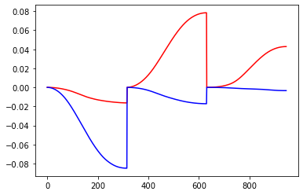

```python
plt.plot(range(0,pca_task36.components_.shape[1]),pca_task36.components_[0], color='red')
plt.plot(range(0,pca_task36.components_.shape[1]),pca_task36.components_[1], color='blue')
plt.show()
```

```python
pca_task37 = PCA(n_components=2)
principalComponents37 = pca_task37.fit_transform(conc_data7)

pca_task37.explained_variance_ratio_
```

```
array([0.69946135, 0.18344972])
```

```python
np.sum(pca_task37.explained_variance_ratio_)
```

```
0.882911072418524
```

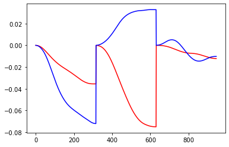

```python
plt.plot(range(0,pca_task37.components_.shape[1]),pca_task37.components_[0], color='red')
plt.plot(range(0,pca_task37.components_.shape[1]),pca_task37.components_[1], color='blue')
plt.show()
```

```python
pca_task38 = PCA(n_components=2)
principalComponents38 = pca_task38.fit_transform(conc_data8)

pca_task38.explained_variance_ratio_
```

```
array([0.52434582, 0.31703177])
```

```python
np.sum(pca_task38.explained_variance_ratio_)
```

```
0.8413775885861182
```

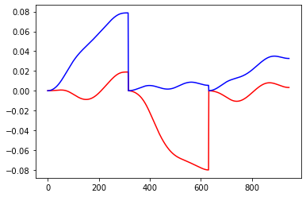

```python
plt.plot(range(0,pca_task38.components_.shape[1]),pca_task38.components_[0], color='red')
plt.plot(range(0,pca_task38.components_.shape[1]),pca_task38.components_[1], color='blue')
plt.show()
```

The patterns in the plots shows clearly that each dimension has its own eigenvector pattern independent of each other, that is, the time series is not smooth as the transition from one dimension to another is clearly seen.In all 8 classes different dimension variations are attributed to different vectors. That is, the variation explained by the first eigenvector corresponds mostly to variation in the first dimension in class 5, e.g.